# Chapter 7: Moving Beyond Linearity

Solutions to Exercises

February 4, 2016

## CONCEPTUAL

> EXERCISE 1:

**Part a)**

[*… will come back to this. maybe.*]

**Part b)**

[*… will come back to this. maybe.*]

**Part c)**

[*… will come back to this. maybe.*]

**Part d)**

[*… will come back to this. maybe.*]

**Part e)**

[*… will come back to this. maybe.*]

> EXERCISE 2:

**Part a)**

When $\lambda=\infty$, first term does not matter. $g^{(0)}=g=0$ means $\hat g$ must be 0

**Part b)**

When $\lambda=\infty$, first term does not matter. $g^{(1)}=g'=0$ means $\hat g$ must be constant (horizontal line).

**Part c)**

When $\lambda=\infty$, first term does not matter. $g^{(2)}=g''=0$ means $\hat g$ must be a straight line like $3x+2$.

**Part d)**

When $\lambda=\infty$, first term does not matter. $g^{(3)}=g'''=0$ means $\hat g$ must be a smooth quadratic curve like $x^2$.

**Part e)**

> EXERCISE 3:
- $X < 1: Y=1+X$
- $X \geq 1: Y=1+X-2(X-1)^2$

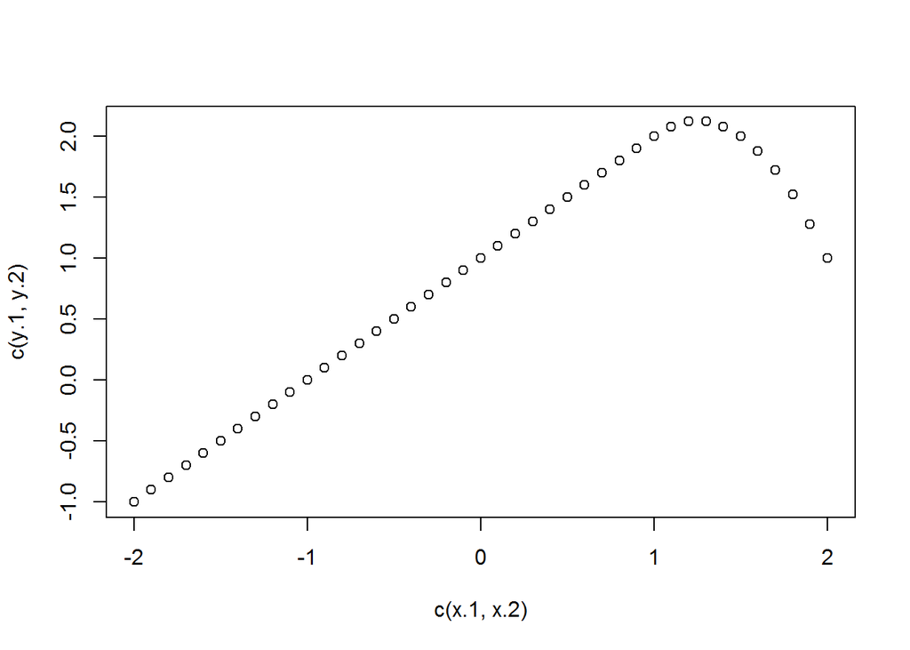

```r
x.1 <- seq(-2,1,0.1)  # X<1
x.2 <- seq(1,2,0.1)   # X>=1
y.1 <- 1 + x.1
y.2 <- 1 + x.2 - 2*(x.2-1)^2
plot(c(x.1,x.2),c(y.1,y.2))
```

> EXERCISE 4:

Plugging in the coefficients, $\hat Y = 1 + b_1(X) + 3b_2(X)$

- $X < 0: Y = 1 + (0) + 3(0) = 1$
- $0\leq X< 1: 1 + (1) + 3(0) = 2$
- $1\leq X\leq 2: 1 + (1-(X-1)) + 3(0) = 3-X$
- $2< X< 3: 1 + (0) + 3(0) = 1$
- $3\leq X\leq 4: 1 + (0) + 3(X-3) = 3X-8$
- $4< X\leq 5: 1 + (0) + 3(1) = 4$
- $X > 5: 1 + (0) + 3(0) = 1$

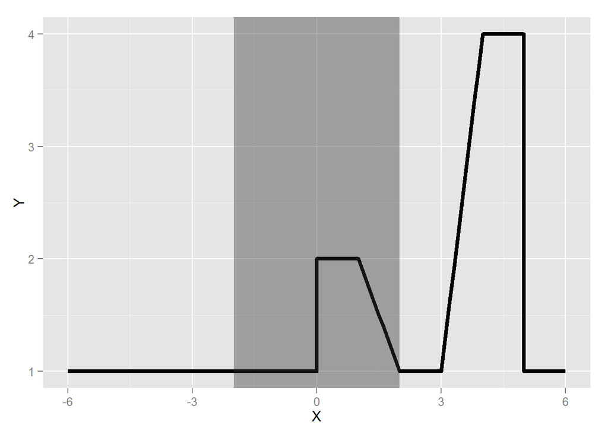

```r
require(ggplot2)
x.1 <- seq(-6, 0, 0.1)  # [-6,0)
x.2 <- seq(0, 1, 0.1)   # [0,1)
x.3 <- seq(1, 2, 0.1)   # [1,2]
x.4 <- seq(2, 3, 0.1)   # (2,3)
x.5 <- seq(3, 4, 0.1)   # [3,4]
x.6 <- seq(4, 5, 0.1)   # (4,5]
x.7 <- seq(5, 6, 0.1)   # (5,6)
y.1 <- rep(1, length(x.1))
y.2 <- rep(2, length(x.2))
y.3 <- 3 - x.3
y.4 <- rep(1, length(x.4))
y.5 <- 3*x.5 - 8
y.6 <- rep(4, length(x.6))
y.7 <- rep(1, length(x.7))
df <- data.frame(X = c(x.1,x.2,x.3,x.4,x.5,x.6,x.7),
                 Y = c(y.1,y.2,y.3,y.4,y.5,y.6,y.7))
p <- ggplot(df, aes(x=X,y=Y)) + geom_line(size=1.5)
rect <- data.frame(xmin=-2, xmax=2, ymin=-Inf, ymax=Inf)
p + geom_rect(data=rect, aes(xmin=xmin, xmax=xmax, ymin=ymin, ymax=ymax),
              fill="grey20",
              alpha=0.4,
              inherit.aes = FALSE)
```

> EXERCISE 5:

**Part a)**

Because $g^{(3)}$ is more stringent on its smoothness requirements then $g^{(4)}$, we’d expect $\hat g_2$ to be more flexible and be able to have a better fit to the training data and thus a smaller training RSS.

**Part b)**

Hard to say. Depends on true form of $y$. If $\hat g_2$ overfits the data because of its increased flexibility, then $\hat g_1$ will likely have a better test RSS.

**Part c)**

When $\lambda=0$, only the first term matters, which is the same for both $\hat g_1$ and $\hat g_2$. The two equations become the same and they would have the same training and test RSS.